# Instrumental Variables

EC 325: Econometrics

Prof. Caraher

Colby College

2026-04-28

## Econometrics So Far

- Causal inference toolkit:
  - **RCTs**: gold standard, but rarely available
  - **Multivariate OLS**: control variables for selection on observables
  - **Fixed effects**: control for time-invariant unobservables in panel data
  - **DiD**: control units instead of control variables
- Each of these requires *something* to work:
  - RCTs need randomization
  - FE needs panel data and time-invariant confounding
  - DiD needs a clean treatment vs. control comparison and parallel trends
- What if we have **none** of these? Just one cross-section, treatment is endogenous, no natural experiment in sight?
- Today: a different angle on causal inference — **instrumental variables (IV)**

## The Promise of IV

- IV asks a *very* different question:

> *“Can we find some external force that ‘shakes up’ our endogenous variable in a way that has nothing to do with the things biasing OLS?”*
- If yes, we can use that external force — the **instrument** — to recover the causal effect
- If no, we have to keep looking

# The Endogeneity Problem

## When OLS Fails

- Recall the OLS unbiasedness condition: the **zero conditional mean assumption**

$$E[\mu \mid X] = 0$$

- When this fails — when $X$ is correlated with $\mu$ — $\hat{\beta}_{OLS}$ is biased
- We call the variable $X$ causing the problem an **endogenous** variable
- Three classic sources of endogeneity:
  1. **Omitted variable bias**
  2. **Selection bias**
  3. **Reverse causality**

## Source 1: Omitted Variable Bias

- We have discussed this a lot!
- Suppose we want to estimate the effect of **education on wages**

$$wage_i = \beta_0 + \beta_1 educ_i + \mu_i$$

- **Ability** affects both education choices and wages
- We can’t measure ability $\rightarrow$ it gets absorbed into $\mu_i$
- Result: $Cov(educ, \mu) \neq 0$, OLS is biased
- This is the classic “ability bias”

## Source 2: Selection Bias

- Want to estimate the effect of **health insurance on health outcomes**
- Healthier people are *more likely* to purchase insurance
- People with insurance are healthier *because* they were healthier to begin with
- The comparison group is contaminated by selection
- Result: $Cov(insurance, \mu) \neq 0$, OLS overstates how much insurance “causes” good health

## Source 3: Reverse Causality

- Want to estimate the effect of **police on crime**
- High-crime areas get more police deployed
- Causation runs both ways: police $\to$ crime, *and* crime $\to$ police
- OLS conflates the two
- Result: positive correlation between police and crime — making it look like police *cause* crime!

## Common Thread

- In all three cases, $X$ contains variation correlated with $\mu$
  - $X$ contains ability; $X$ is contaminated with selection bias; or $X$ reverse-causes $Y$
- We need a way to use **only the part of $X$ that is unrelated to $\mu$**
- Enter: **instrumental variables**

# The Instrumental Variables Idea

## Endogenous vs. Exogenous Variation

- Think of total variation in $X$ as having two types:

**Bad (“endogenous”) variation**

- The part of $X$ correlated with $\mu$
- This is what biases OLS
- We want to *throw it away*

**Good (“exogenous”) variation**

- The part of $X$ unrelated to $\mu$
- This is what we want
- We need to *isolate* it
- IV finds an external variable $Z$ — the **instrument** — that “zooms in” to exogenous variation in $X$
- We then use *only* that variation to estimate the causal effect

## What Makes an Instrument Valid?

- For $Z$ to work as an instrument, it must satisfy **two assumptions**
1. **Relevance**
2. **Exclusion restriction**
- Both must hold. If either one fails, the instrument does *not* isolate clean variation in $X$
- We’ll take them one at a time

## Assumption 1: Relevance

**Relevance**

$$Cov(Z, X) \neq 0$$

The instrument must move the endogenous variable.

- The instrument must actually do *some* work in shifting $X$
- If $Z$ has no effect on $X$, then there’s no exogenous variation to use — IV gives nothing
- This is the **testable** IV assumption:
  - Regress $X$ on $Z$
  - Look at the first-stage F-statistic (more on this later in the deck)

## Assumption 2: Exclusion Restriction

**Exclusion Restriction**

$$Cov(Z, \mu) = 0$$

The instrument affects $Y$ **only through** $X$. There is no direct effect of $Z$ on $Y$.

- This is what turns a correlation into a causal effect
- It says: *the only way $Z$ can move $Y$ is by first moving $X$*
- This assumption is **not testable** — there’s no statistical test for it
- It has to be defended with **economic reasoning**
- Most of the work in any IV paper is defending this assumption

# A Running Example: Angrist & Evans (1998)

## The Research Question

- What is the causal effect of having an additional child on a mother’s labor force participation?
- Important for:
  - Understanding the gender wage gap
  - Designing parental leave and childcare policy
- But fertility is **deeply endogenous**:
- **Reverse causality**: women time fertility around their careers
- **Selection**: less career-oriented women may choose larger families
- **OVB**: unobserved preferences drive both fertility and work
- OLS regression of employment on number of kids tangles all of this together

## The Clever Instrument

- Angrist and Evans (1998) propose using the **sex composition of the first two children**
- The idea: parents have a slight preference for **mixed-sex children**
  - Two boys $\to$ slightly more likely to try for a third (hoping for a girl)
  - Two girls $\to$ same logic in reverse
  - One of each $\to$ less reason to have a third
- The sex of a child is essentially biological chance $\to$ same-sex vs. mixed-sex is **as good as random**

## Why This Is a Good Instrument

**Relevance** ($Cov(Z, X) \neq 0$)

- Same-sex parents *are* more likely to have a third child
- We can verify this in the data (and we will!)
- This is testable

**Exclusion** ($Cov(Z, \mu) = 0$)

- Sex composition is essentially random with respect to career orientation, husband’s earnings, etc.
- Hard to imagine a *direct* channel from “two boys” to “mom works less”
- Plausible, but **not testable**
- With the study in hand, we can now draw the diagram

# Graphical Intuition: The IV DAG

## Step 1: The Confounding Problem

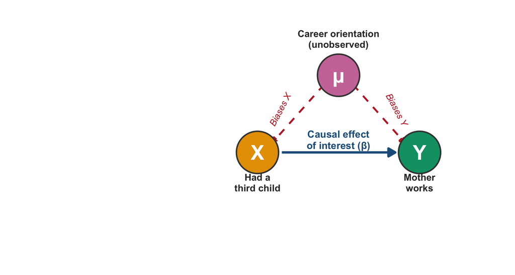

- We *want* the $X \to Y$ arrow — the parameter $\beta$
- But the unobserved confounder $\mu$ creates a **backdoor path**: $X \leftarrow \mu \to Y$
- Career-minded women have fewer kids *and* are more likely to work $\to$ OLS confuses the two channels

## Step 2: Bring in the Instrument

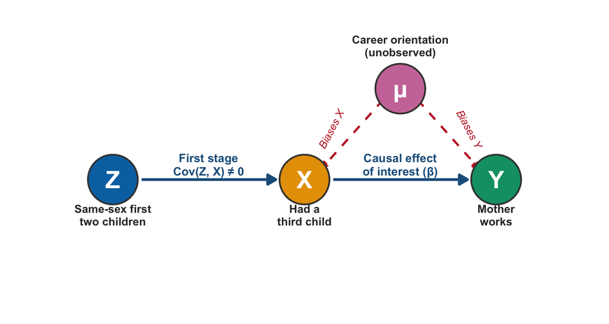

- $Z$ shifts $X$ but is *itself* unaffected by $\mu$
- $Z$ injects clean, exogenous variation into $X$ that we can use

## Step 3: The Crucial *Missing* Arrow

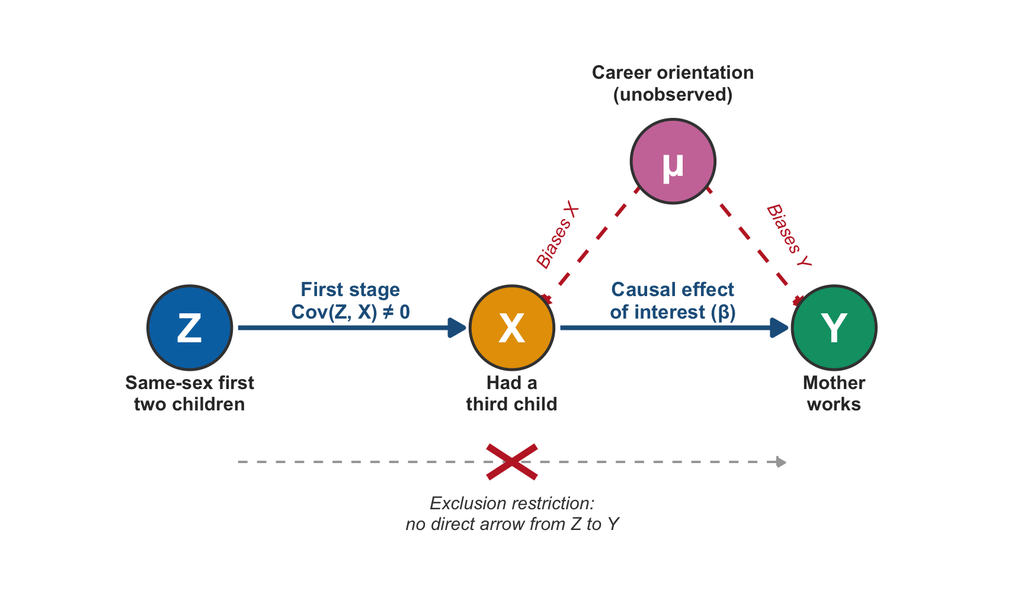

- The exclusion restriction is what we *don’t* see: no direct $Z \to Y$ arrow
- $Z$ can reach $Y$ **only** by going through $X$
- This is what makes IV identify $\beta$

# Simulating Angrist & Evans

## The Simulated Setup

- $N = 50{,}000$ mothers (synthetic data, but designed to match Angrist-Evans)
- We *know* the truth because we built it:

| Variable | Description | Effect on… |
| --- | --- | --- |
| `career_orientation` | Unobserved $\mu$ | $\downarrow$ fertility, $\uparrow$ work |
| `samesex` | Instrument $Z$ | $\uparrow$ fertility |
| `morekids` | Treatment $X$ | $\downarrow$ work (true $\beta = -0.10$) |
| `mom_worked` | Outcome $Y$ | — |

- Goal: see whether OLS recovers $\beta = -0.10$. (Spoiler: it doesn’t. IV does.)

## Testing Relevance

```r
relevance_check <- ae_sim |>
    group_by(samesex_lab) |>
    summarize(prop_morekids = mean(morekids))

relevance_check
```

```
# A tibble: 2 × 2
  samesex_lab prop_morekids
  <chr>               <dbl>
1 Mixed sex           0.196
2 Same sex            0.258
```

- Same-sex parents are noticeably more likely to have a third child

## Testing Relevance

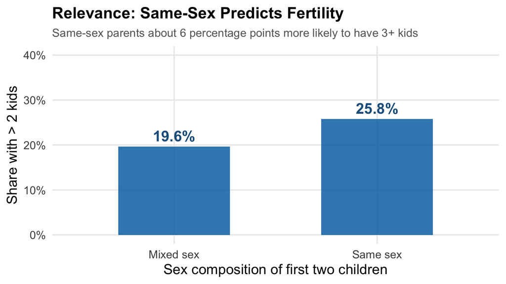

Figure 1

## “Testing” Excludability

- We **can’t** directly test the exclusion restriction
- But we can do a sanity check: is the *reduced-form* effect of $Z$ on $Y$ small?

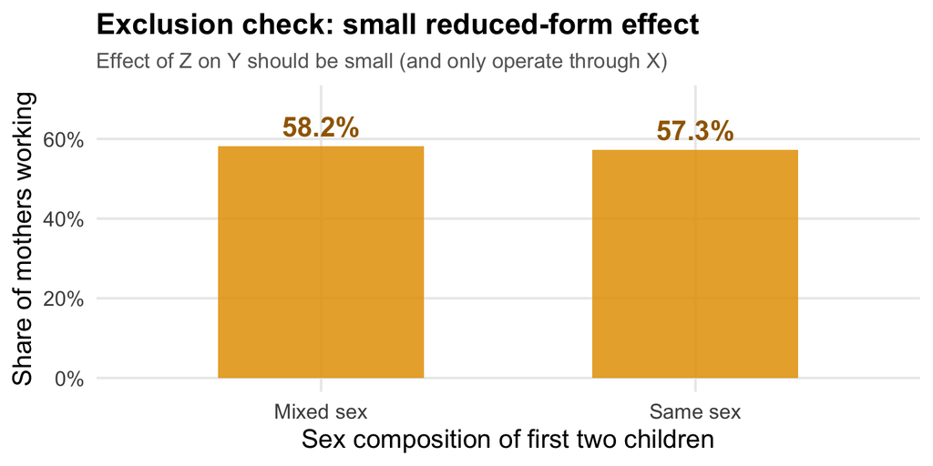

Figure 2

## Reading the Reduced-Form

- The difference is small (around a percentage point)
- Consistent with the effect operating through fertility, not directly
- This **doesn’t prove** excludability — we still rely on the economic argument
- But it’s at least *consistent* with the assumption

# Two-Stage Least Squares (2SLS)

## The 2SLS Strategy

- IV is typically estimated using **Two-Stage Least Squares (2SLS)**

**Stage 1 (First Stage):** regress endogenous variable on the instrument

$$X_i = \pi_0 + \pi_1 Z_i + \nu_i$$

Get predicted values: $\hat{X}_i = \hat{\pi}_0 + \hat{\pi}_1 Z_i$

These predicted values contain *only* the variation in $X$ that comes from $Z$

**Stage 2 (Second Stage):** regress outcome on the predicted values

$$Y_i = \beta_0 + \beta_1 \hat{X}_i + \varepsilon_i$$

The coefficient $\hat{\beta}_1^{2SLS}$ is our causal estimate

## Why Does 2SLS Work?

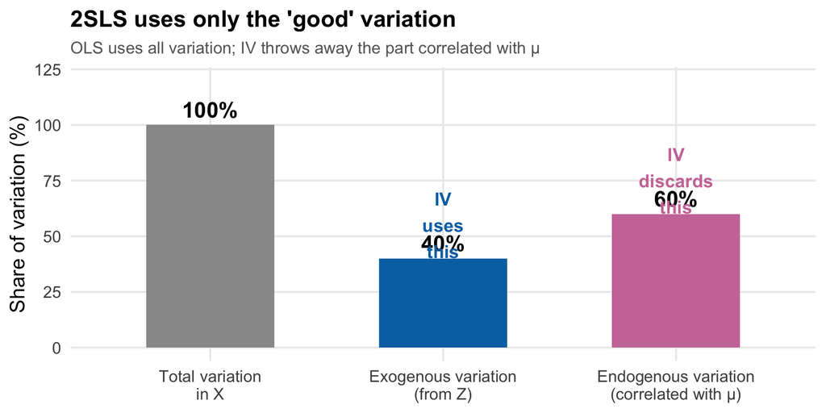

Figure 3

## Manual 2SLS: Step 1

```r
# First stage: regress endogenous variable on instrument
first_stage <- lm(morekids ~ samesex, data = ae_sim)

summary(first_stage)$coefficients
```

```
              Estimate  Std. Error  t value
(Intercept) 0.19628848 0.002636030 74.46368
samesex     0.06153626 0.003736213 16.47022
                                                                         Pr(>|t|)
(Intercept) 0.0000000000000000000000000000000000000000000000000000000000000000000
samesex     0.0000000000000000000000000000000000000000000000000000000000008687359
```

- The first-stage coefficient on `samesex` says: if your first two kids are the same sex, your probability of having a third rises by ~6 percentage points
- The F-statistic on the instrument is well into the hundreds: a strong first stage

## Manual 2SLS: Step 2

```r
# Get predicted values from first stage
ae_sim <- ae_sim |>
    mutate(morekids_hat = predict(first_stage))

ae_sim |>
    select(samesex, morekids, morekids_hat) |>
    head(8)
```

```
# A tibble: 8 × 3
  samesex morekids morekids_hat
    <int>    <int>        <dbl>
1       1        0        0.258
2       0        0        0.196
3       0        1        0.196
4       1        0        0.258
5       1        0        0.258
6       1        0        0.258
7       1        0        0.258
8       1        0        0.258
```

- `morekids_hat` takes only **two values** — one for each value of `samesex`
- This is the *exogenous part* of `morekids`

## Manual 2SLS: Step 3

```r
# Second stage: regress outcome on predicted values
second_stage_manual <- lm(mom_worked ~ morekids_hat, data = ae_sim)
coef(second_stage_manual)["morekids_hat"]
```

```
morekids_hat
  -0.1584669
```

**Standard error warning**

The manual two-stage approach gives the *correct coefficient*, but the **standard errors are wrong** — they don’t account for first-stage uncertainty.

**Always use a proper 2SLS estimator** (e.g. `feols()`).

# Estimating IV with `feols()`

## The `feols()` 4-Part Formula

```r
outcome ~ exogenous_controls | fixed_effects | endogenous ~ instrument(s)
```

| Slot | What goes here |
| --- | --- |
| `outcome` | Dependent variable $Y$ |
| `exogenous_controls` | Covariates that are *not* endogenous; use `1` if none |
| `fixed_effects` | Variables to absorb as FEs; use `0` if none |
| `endogenous ~ instrument(s)` | The first-stage formula |

## A Bare-Bones IV

```r
tsls <- feols(mom_worked ~ 1 |  0  | morekids ~ samesex,
              data = ae_sim)

summary(tsls)
```

```
TSLS estimation - Dep. Var.: mom_worked
                  Endo.    : morekids
                  Instr.   : samesex
Second stage: Dep. Var.: mom_worked
Observations: 50,000
Standard-errors: IID
              Estimate Std. Error  t value  Pr(>|t|)
(Intercept)   0.613519   0.015972 38.41160 < 2.2e-16 ***
fit_morekids -0.158467   0.069749 -2.27196  0.023093 *
---
Signif. codes:  0 '***' 0.001 '**' 0.01 '*' 0.05 '.' 0.1 ' ' 1
RMSE: 0.479855   Adj. R2: 7.743e-5
F-test (1st stage), morekids: stat = 271.2683, p < 2.2e-16 , on 1 and 49,998 DoF.
                  Wu-Hausman: stat =   5.9324, p = 0.014869, on 1 and 49,997 DoF.
```

## What to Look At

- **`fit_morekids`**: the 2SLS estimate of $\beta$ (the `fit_` prefix flags the fitted endogenous variable)
- **Std. error**: the *correct* 2SLS SE (not the broken manual one)
- **F-test (1st stage)**: a built-in instrument-strength diagnostic
- The 2SLS estimate should be close to the true $-0.10$ — much closer than OLS will get

## Inspecting the First Stage

- `feols()` runs the first stage internally but hides it. Pass `stage = 1` to expose it:

```r
summary(tsls, stage = 1)
```

```
TSLS estimation - Dep. Var.: morekids
                  Endo.    : morekids
                  Instr.   : samesex
First stage: Dep. Var.: morekids
Observations: 50,000
Standard-errors: IID
            Estimate Std. Error t value  Pr(>|t|)
(Intercept) 0.196288   0.002636 74.4637 < 2.2e-16 ***
samesex     0.061536   0.003736 16.4702 < 2.2e-16 ***
---
Signif. codes:  0 '***' 0.001 '**' 0.01 '*' 0.05 '.' 0.1 ' ' 1
RMSE: 0.417709   Adj. R2: 0.005376
F-test (1st stage): stat = 271.27, p < 2.2e-16, on 1 and 49,998 DoF.
```

## Adding Controls

- Exogenous controls go in the **first slot**
- They are automatically included in *both* stages

```r
# Illustrative
tsls_ctrl <- feols(mom_worked ~ age + education |
                       0 |
                       morekids ~ samesex,
                   data = ae_sim)
```

- Use this for variables you want to control for that aren’t themselves endogenous (mother’s age, education, etc.)

## Adding Fixed Effects

- Fixed effects go in the **second slot**
- Absorbed efficiently — much faster than creating dummies on big data

```r
# Illustrative
tsls_fe <- feols(mom_worked ~ age + education |
                     state |
                     morekids ~ samesex,
                 data = ae_sim)
```

- Equivalent to including state dummies in *both* stages, but vastly faster

## Multiple Instruments

- Adding a second instrument is just a `+` in the first-stage formula

```r
# Illustrative: add 'twins' as a second instrument for fertility
tsls_multi <- feols(mom_worked ~ 1 |
                        0 |
                        morekids ~ samesex + twins,
                    data = ae_sim)
```

**Why might you want multiple instruments?**

- More first-stage variation in $X$ $\to$ generally smaller standard errors and tighter inference
- Lets you *cross-check* your instruments: if two supposedly valid instruments produce very different 2SLS estimates, at least one is probably bad

**What does “overidentified” mean?**

- More instruments than endogenous variables $\to$ the model is **overidentified**
- 2SLS combines the instruments into a single weighted prediction of $X$

**But more instruments aren’t free**

- Each new instrument carries its **own exclusion restriction** to defend — one bad instrument contaminates the whole estimate
- The “**many weak instruments**” problem: adding marginally-relevant instruments can *amplify* finite-sample bias and drag 2SLS back toward OLS
- A few strong instruments usually beat many weak ones

## Cluster-Robust Standard Errors

- IV standard errors are sensitive to within-cluster correlation
- `feols()` makes this easy:

```r
# Cluster at estimation time
feols(mom_worked ~ 1 | 0 | morekids ~ samesex,
      cluster = ~ state,
      data = ae_sim)

# Or after the fact
summary(tsls, cluster = ~ state)
```

- Same advice as for DiD: cluster at the level of treatment assignment

# Weak Instruments

## Why Weak Instruments Are Dangerous

- If the instrument is only *weakly* correlated with $X$:
  - Tiny changes in the data produce wild swings in $\hat{\beta}^{2SLS}$
  - Estimates can become biased *toward* OLS (the very thing we were trying to escape!)
  - Standard errors become unreliable
  - Inference breaks

**Warning**

2SLS with a weak instrument is sometimes *worse* than just running OLS.

## The First-Stage F-Test

- The standard diagnostic for instrument strength is the **first-stage F-statistic**
- It tests $H_0: \pi_1 = 0$ in the first-stage regression

$$X_i = \pi_0 + \pi_1 Z_i + \nu_i$$

- **Single instrument**: F is just the squared t-statistic on $\pi_1$
- **Multiple instruments**: F is the joint test that *none* of them predict $X$
- A large F means the instruments collectively move $X$ around a lot

## The Traditional “F > 10” Rule

- Long-standing rule of thumb: a first-stage **F above 10** is “strong enough”
- Comes from Stock and Yogo (2005)
- Has been the textbook standard for two decades

**The classic rule**

$F \geq 10 \implies$ instrument is strong enough to trust 2SLS.

## Recent Evidence: 10 Is Too Lenient

- Lee, McCrary, Moreira, and Porter (2022) show: to justify standard t-test inference on the 2SLS coefficient, you need an F closer to **100** than 10
- An instrument with $F = 20$ may have fine point estimates, but its confidence intervals are **too narrow**
- Lots of “significant” results in IV papers may not really be

**A safer modern default**

Treat $F \in [10, 100]$ with caution. Prefer instruments with much higher first-stage F when you can find them.

## What Happens with a Weak Instrument?

```r
# Replace samesex with random noise --- a useless instrument
set.seed(123)
ae_sim <- ae_sim |>
    mutate(weak_instrument = rnorm(n()))

weak_iv <- feols(mom_worked ~ 1 | 0 | morekids ~ weak_instrument,
                 data = ae_sim)

summary(weak_iv)
```

```
TSLS estimation - Dep. Var.: mom_worked
                  Endo.    : morekids
                  Instr.   : weak_instrument
Second stage: Dep. Var.: mom_worked
Observations: 50,000
Standard-errors: IID
             Estimate Std. Error   t value Pr(>|t|)
(Intercept)   2.65321    7.33938  0.361504  0.71772
fit_morekids -9.14707   32.34337 -0.282811  0.77732
---
Signif. codes:  0 '***' 0.001 '**' 0.01 '*' 0.05 '.' 0.1 ' ' 1
RMSE: 3.72496   Adj. R2: 7.098e-5
F-test (1st stage), morekids: stat = 0.07561, p = 0.783339, on 1 and 49,998 DoF.
                  Wu-Hausman: stat = 4.58052, p = 0.032342, on 1 and 49,997 DoF.
```

## Strong vs. Weak: 100 Random Instruments

- Was that one wild fit a fluke? Let’s run 2SLS with **100 different random instruments** and see how stable the estimates are.

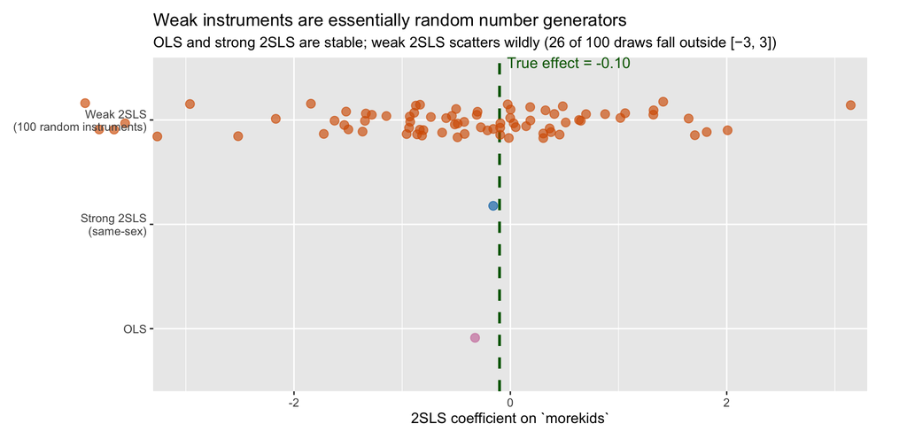

Figure 4

## The Lesson

- **Always check your first-stage F-statistic**
- A weak instrument can be more misleading than no instrument
- So if you have a weak instrument, you need to stop

# IV Diagnostics

## Computing the Diagnostics

- After estimating, pull out the IV diagnostics with `fitstat()`:

```r
fitstat(tsls, ~ ivf + ivwald + wh)
```

```
F-test (1st stage), morekids: stat = 271.2683, p < 2.2e-16 , on 1 and 49,998 DoF.
Wald (1st stage), morekids  : stat = 271.2683, p < 2.2e-16 , on 1 and 49,998 DoF, VCOV: IID.
                  Wu-Hausman: stat =   5.9324, p = 0.014869, on 1 and 49,997 DoF.
```

## What Each One Tests

**`ivf` — First-stage F (homoskedastic)**

**Null:** the instrument doesn’t predict $X$ ($\pi_1 = 0$). **Reads as:** large F = strong first stage; small F = weak instrument problem. **Use:** the standard relevance check.

**`ivwald` — Robust first-stage F (Wald form)**

**Null:** same as `ivf`, but computed with the robust variance-covariance matrix. **Reads as:** with clustered or heteroskedasticity-robust SEs, this is the version you should trust — the homoskedastic `ivf` can mislead. **Use:** report instead of `ivf` whenever you cluster.

**`wh` — Wu-Hausman endogeneity test**

**Null:** $X$ is exogenous (so OLS would be unbiased). **Reads as:** compares OLS and 2SLS coefficients. Similar $\to$ fail to reject $\to$ OLS may suffice. Very different $\to$ reject $\to$ IV is doing necessary work. **Use:** sanity-check that you actually *need* IV in the first place.

# OLS vs. 2SLS

## Side-by-Side

```r
# OLS for comparison (biased)
ols <- lm(mom_worked ~ morekids, data = ae_sim)
```

```r
modelsummary::modelsummary(
    list("OLS (biased)" = ols, "2SLS (IV)" = tsls),
    coef_map = c("morekids" = "morekids", "fit_morekids" = "morekids"),
    gof_map = c("nobs", "r.squared"),
    output = "markdown"
)
```

|  | OLS (biased) | 2SLS (IV) |
| --- | --- | --- |
| morekids | -0.326 | -0.158 |
|  | (0.005) | (0.070) |
| Num.Obs. | 50000 | 50000 |
| R2 | 0.076 | 0.000 |

## OLS vs. 2SLS: Visual

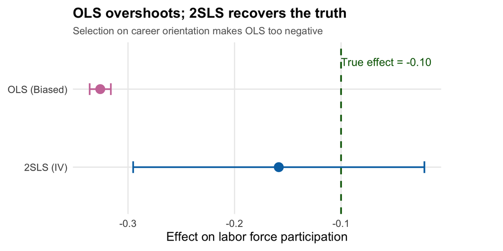

Figure 5

## What Went Wrong with OLS?

- OLS estimate is *more negative* than the truth
- Because of selection on **career orientation**:
  - Less career-oriented women have more children *and* work less
  - $\rightarrow$ OLS makes children look worse for employment than they really are
- 2SLS uses only the random variation from same-sex composition $\rightarrow$ recovers the truth

# Classic IV Applications

## A Map of the Greatest Hits

| Study | Question | Instrument |
| --- | --- | --- |
| **Card (1995)** | Returns to education | Distance to college |
| **Acemoglu, Johnson & Robinson (2001)** | Do institutions cause growth? | Colonial settler mortality |
| **Levitt (1997)** | Effect of police on crime | Electoral timing |
| **Angrist & Krueger (1991)** | Returns to education | Quarter of birth |

- Each one uses the same recipe: question $\to$ source of endogeneity $\to$ instrument $\to$ defend exclusion

## Card (1995): Returns to Education

- **Question:** What is the causal effect of education on wages?
- **Problem:** Ability is unobserved; biases OLS upward
- **Instrument:** Distance to the nearest college growing up
- **Why relevant?** Proximity reduces the cost of attending college
- **Why excludable?** Distance to a college shouldn’t directly affect wages decades later — only through education
- **Finding:** Returns to education are *higher* than OLS suggests
  - Ability bias works in the opposite direction from what many had assumed!

## Acemoglu, Johnson & Robinson (2001): Institutions

- **Question:** Do institutions (rule of law, property rights) cause long-run growth?
- **Problem:** Rich countries can afford better institutions $\rightarrow$ reverse causality
- **Instrument:** Colonial settler mortality rates (17th–19th century)
  - High mortality $\rightarrow$ extractive colonies $\rightarrow$ bad institutions
  - Low mortality $\rightarrow$ settler colonies $\rightarrow$ inclusive institutions
- **Why relevant?** Colonial institutional form persisted to the present
- **Why excludable?** European mortality from disease 200+ years ago shouldn’t directly affect today’s GDP — only through the institutions it shaped
- **Finding:** Institutions have a *large* causal effect on GDP per capita; sparked the “institutions vs. geography” debate

## Levitt (1997): Police and Crime

- **Question:** Does hiring more police cause crime to fall?
- **Problem:** Reverse causality — high-crime cities hire more police, making OLS look like police *cause* crime
- **Instrument:** Timing of mayoral and gubernatorial elections (police hiring spikes pre-election)
- **Why relevant?** Police staffing rises predictably before elections
- **Why excludable?** The electoral calendar is set by law, not by recent crime trends
- **Finding:** More police *substantially* reduce crime — IV estimate flips the (wrong-signed) OLS correlation
- A coding error was later corrected by McCrary (2002); the violent-crime effect survives but is smaller

## Angrist & Krueger (1991): Quarter of Birth

- **Question:** What is the causal return to schooling on earnings?
- **Problem:** Ability bias (same as Card)
- **Instrument:** Quarter of birth, interacted with compulsory schooling laws
  - Q1 babies start school *older*, hit dropout age with *less* education
  - Q4 babies start school *younger*, are forced to stay in *longer*
- **Why relevant?** First-stage relationship is detectable but modest
- **Why excludable?** Quarter of birth is essentially random with respect to ability/family background
- **Finding:** IV estimates close to OLS $\rightarrow$ ability bias may be smaller than feared
- Bound, Jaeger, and Baker (1995) later showed quarter of birth is a *weak* instrument — one of the motivating examples for the weak-IV literature

# Wrapping Up

## Key Takeaways

**What you need for IV to work**

**1. Relevance** ($Cov(Z, X) \neq 0$): the instrument predicts $X$. Testable via the first-stage F.

**2. Exclusion** ($Cov(Z, \mu) = 0$): $Z$ affects $Y$ only through $X$. *Not* testable — defend with economic reasoning.

- 2SLS uses *only* the exogenous variation in $X$ induced by $Z$
- Weak instruments produce unreliable estimates — check the first-stage F (and don’t trust 10!)
- `feols()` makes 2SLS easy: `outcome ~ controls | FEs | endogenous ~ instrument`